```python
from nearest_neighbors import KNNClassifier
from cross_validation import knn_cross_val_score
import matplotlib.pyplot as plt
from sklearn.model_selection import KFold
from sklearn.metrics import confusion_matrix
import numpy as np
import time
%matplotlib inline
```

# Проничкин Юрий

```python
import idx2numpy
```

# Загружаем тренировочную и тестовую выборки с помощью idx2numpy

```python
X_train = idx2numpy.convert_from_file('train-images.idx3-ubyte')
```

```python
y_train = idx2numpy.convert_from_file('train-labels.idx1-ubyte')
```

```python
X_test = idx2numpy.convert_from_file('t10k-images.idx3-ubyte')
```

```python
y_test = idx2numpy.convert_from_file('t10k-labels.idx1-ubyte')
```

# Тест времени

Создаем словарь алгоритмов и в цикле по размеру вектора признаков и словарю получаем нужные времена

```python
dict_of_algs = { 1 : 'my_own', 2: 'brute', 3: 'kd_tree', 4: 'ball_tree'}
dict_of_times = { 1 : [], 2 : [], 3 : [], 4 : []}
for n in [10, 20, 100]:
    features = np.random.choice(28 * 28, n, False)
    for alg in range(1, 5):
        knn = KNNClassifier(5, dict_of_algs[alg], 'euclidean', False, 100)
        knn.fit(X_train.reshape(-1, 784)[:, features], y_train)
        curr_time = time.time()
        knn.predict(X_test.reshape(-1, 784)[:, features])
        dict_of_times[alg].append(time.time() - curr_time)
```

```python
dict_of_times
```

```
{1: [75.4424901008606, 81.38876008987427, 153.56450176239014],
 2: [21.38561511039734, 24.880481481552124, 29.16017484664917],
 3: [2.401068925857544, 11.230978727340698, 132.80559301376343],
 4: [5.417897462844849, 27.041287899017334, 113.9559051990509]}
```

Итак : $$ $$ Собственная реализация: $$ 75.44 \quad 81.38 \quad 153.56$$ brute: $$21.38 \quad 24.88 \quad 29.16$$ kd tree: $$ 2.40 \quad 11.23 \quad 132.80$$ ball tree: $$ 5.41 \quad 27.04 \quad 113.95$$

Здесь очевидно 'проклятье размерности' - на большом количестве признаков kd tree и ball tree начинают работать намного дольше простого brute, который работает не сильно дольше, при этом на маленьких размерностях лучше использовать kd tree и ball tree

# Генерируем фолды и список k числа соседей

```python
def gen_folds(X, y, n):
    list_of_folds = []
    kfold = KFold(n)
    for i in kfold.split(X,y):
        list_of_folds.append(i)
    return list_of_folds
```

```python
Folds = gen_folds(X_train, y_train, 3)
```

```python
k_list = [i for i in range(1, 11)]
```

# Тестируем на евклидовой метрике

```python
curr_time = time.time()
score_dict_euclidean_mo = knn_cross_val_score(X_train.reshape(-1, 784), y_train, k_list, 'accuracy', Folds, strategy='brute', metric='euclidean',weights=False)
time_euclidean_mo = time.time() - curr_time
```

# Время работы

```python
print("Brute euclidean time", time_euclidean_mo)
```

```
Brute euclidean time 317.6748502254486
```

# Результат

```python
score_dict_euclidean_mo
```

```
{1: [0.96895, 0.96675, 0.9667],
 2: [0.9603, 0.95995, 0.96125],
 3: [0.96955, 0.96825, 0.96715],
 4: [0.96705, 0.9667, 0.9671],
 5: [0.9681, 0.9673, 0.9672],
 6: [0.96555, 0.96495, 0.9657],
 7: [0.9652, 0.965, 0.9656],
 8: [0.96415, 0.9639, 0.96525],
 9: [0.9637, 0.9632, 0.96455],
 10: [0.96245, 0.9622, 0.9637]}
```

# То же для косинусовой

```python
curr_time = time.time()
score_dict_cosine_mo = knn_cross_val_score(X_train.reshape(-1, 784), y_train, k_list, 'accuracy', Folds, strategy='brute', metric='cosine',weights=False)
time_coseine_mo = time.time() - curr_time
```

# Время

```python
print("Brute euclidean time", time_coseine_mo)
```

```
Brute euclidean time 485.5541579723358
```

# Точность

```python
score_dict_cosine_mo
```

```
{1: [0.9733, 0.9708, 0.97045],
 2: [0.96895, 0.9664, 0.96775],
 3: [0.97365, 0.97155, 0.9709],
 4: [0.9725, 0.97095, 0.9722],
 5: [0.97275, 0.97015, 0.9716],
 6: [0.97195, 0.9697, 0.97215],
 7: [0.97125, 0.96815, 0.97075],
 8: [0.97125, 0.96835, 0.97155],
 9: [0.97005, 0.967, 0.9707],
 10: [0.96935, 0.96615, 0.9707]}
```

Из результатов видно что косинусное растояние считается в целом дольше, но и дает лучшие результаты длявсех k

# Теперь с весами

```python
score_dict_euclidean_mo_weighted = knn_cross_val_score(X_train.reshape(-1, 784), y_train, k_list, 'accuracy', Folds, strategy='brute', metric='euclidean',weights=True)
```

```python
score_dict_cosine_mo_weighted = knn_cross_val_score(X_train.reshape(-1, 784), y_train, k_list, 'accuracy', Folds, strategy='brute', metric='cosine',weights=True)
```

# Результат евклидовой ...

```python
score_dict_euclidean_mo_weighted
```

```
{1: [0.96895, 0.96675, 0.9667],
 2: [0.96895, 0.96675, 0.9667],
 3: [0.97075, 0.9691, 0.96825],
 4: [0.9713, 0.9698, 0.9701],
 5: [0.96925, 0.96825, 0.96875],
 6: [0.9704, 0.96845, 0.96945],
 7: [0.96735, 0.96595, 0.967],
 8: [0.9676, 0.96665, 0.9678],
 9: [0.9651, 0.9643, 0.9657],
 10: [0.9647, 0.96465, 0.9657]}
```

# ... и косинусной метрик

```python
score_dict_cosine_mo_weighted
```

```
{1: [0.9733, 0.9708, 0.97045],
 2: [0.9733, 0.9708, 0.97045],
 3: [0.97495, 0.9725, 0.97175],
 4: [0.97545, 0.9732, 0.97365],
 5: [0.974, 0.97095, 0.973],
 6: [0.97465, 0.9714, 0.97305],
 7: [0.9726, 0.9693, 0.97195],
 8: [0.97295, 0.97045, 0.9722],
 9: [0.97165, 0.96865, 0.97145],
 10: [0.97145, 0.96855, 0.9714]}
```

Из результатов видно что косинусная метрика в целом лучше классифицирует, при этом взвешенный алгоритм работет лучше в обоих случаях. От туда же примерно лучшие параметры: косинусная метрика, 4 соседа, взвешенно.

# Обучаем с полученными параметрами

```python
knn = KNNClassifier(4, 'brute', 'cosine', True, 100)
```

```python
knn.fit(X_train.reshape(-1,784), y_train)
```

# Предсказания на тестовой выборке

```python
y_predict = knn.predict(X_test.reshape(-1,784))
```

```python
score = (y_predict == y_test).sum() / len(y_predict)
```

# Результат

```python
score
```

```
0.9752
```

Резульаты даже выше чем на крос-валидации. Но википедия https://ru.wikipedia.org/wiki/MNIST_(%D0%B1%D0%B0%D0%B7%D0%B0_%D0%B4%D0%B0%D0%BD%D0%BD%D1%8B%D1%85) говорит что метод knn может работать с еще большей точность - 0.9948

# Матрица ошибок

```python
cm = confusion_matrix(y_test, y_predict)
```

```python
cm
```

```
array([[ 977,    1,    0,    0,    0,    0,    1,    1,    0,    0],
       [   0, 1129,    3,    1,    0,    0,    2,    0,    0,    0],
       [   8,    0, 1009,    1,    1,    0,    0,    8,    5,    0],
       [   0,    1,    3,  976,    1,   12,    0,    4,    9,    4],
       [   2,    1,    0,    0,  946,    0,    6,    2,    0,   25],
       [   4,    0,    0,    9,    1,  863,    7,    1,    4,    3],
       [   3,    3,    0,    0,    1,    3,  948,    0,    0,    0],
       [   2,   10,    4,    0,    1,    0,    0,  998,    0,   13],
       [   7,    1,    2,    9,    3,    3,    5,    4,  936,    4],
       [   7,    7,    2,    5,    7,    3,    1,    4,    3,  970]])
```

Из нее видно что больше всего ошибок на 4-ах распознанных как 9ки и 7-ах распзнанных как 9-ки

# Несколько плохо распознаных цифр

```python
indexes = np.where(mask == False)
```

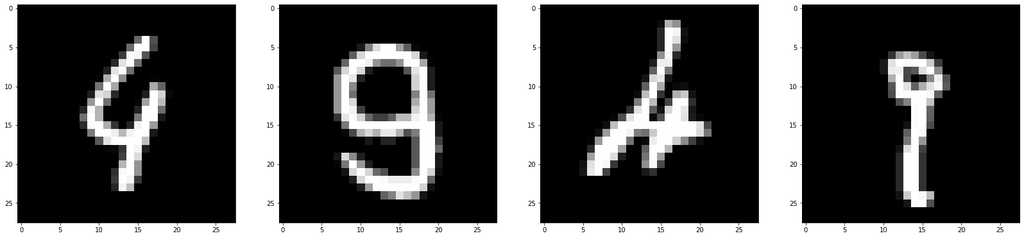

```python
fig, (ax1, ax2, ax3, ax4) = plt.subplots(1, 4, figsize=(28,28))
ax1.imshow(X_test[indexes][0], cmap='gray')
ax2.imshow(X_test[indexes][1], cmap='gray')
ax3.imshow(X_test[indexes][2], cmap='gray')
ax4.imshow(X_test[indexes][3], cmap='gray')
plt.show()
```